# Cort models eval

## Objectives

1. New responses:
- s2 - s1: absolute change
- (s2-s1)/s1: proportional change
1. Do responses satisfy normality?
2. Produce one model with max and one model with min, look at graphically to see what looks nicest
3. Evaluate model:
- fit
- qqplots
- outliers
- residuals vs temp

## Questions for lab meeting

1. If we think that age of nestling mediates their ability to respond to stress (we do), should I test for a 3-way interaction between age, temp, and habitat? Does this make more sense as a formal mediation analysis?
2. I like the idea of parsing out the effect of max temp from min temp, could be a useful comparison to make with previous work looking at the cort effects of cold, and matches our pre-existing expectation that cold and hot operate differently. Based on your understanding of bird physiology, what are the squared temp vs the cold and hot temp models telling us?
3. Reflect on finding that abs change has more of an interactive signal than baseline cort

## Do responses satisfy normality?

## WEBL

### Baseline cort

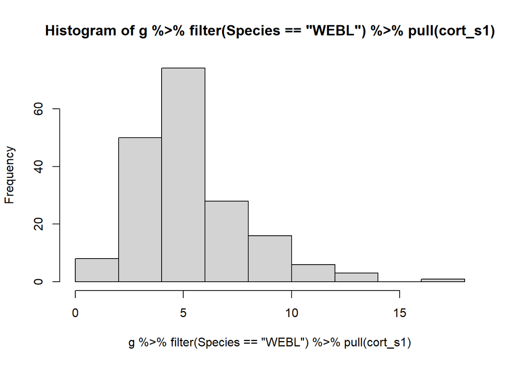

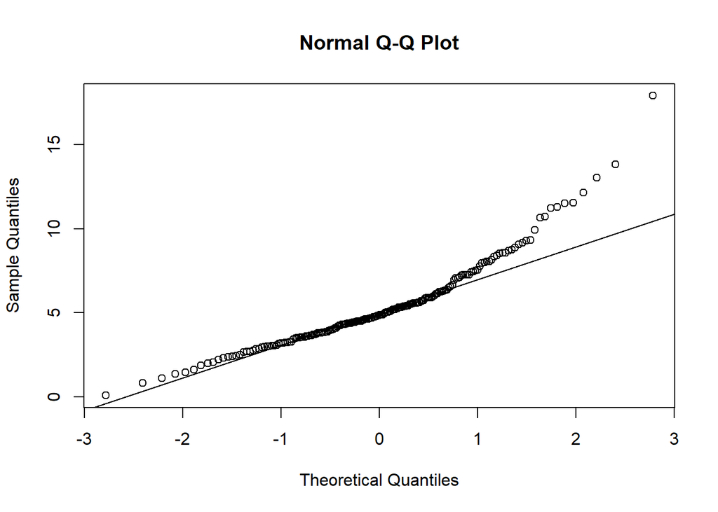

May be basically okay but a transformation may help.

### Square root transformation

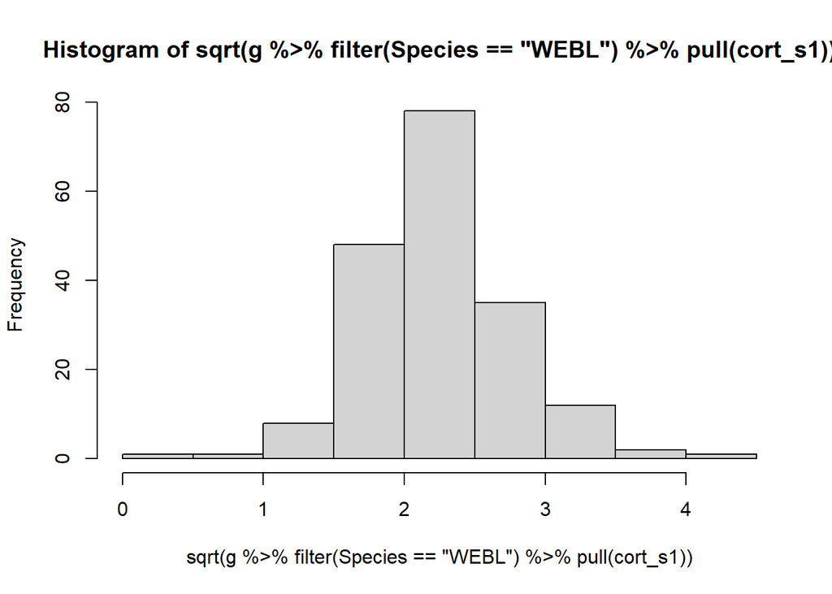

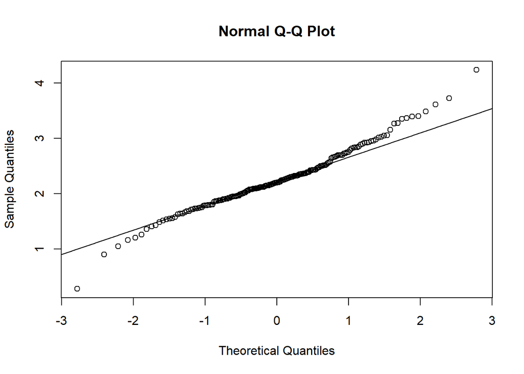

This looks like enough for cort_s1.

### Absolute difference cort_s2-cort_s1

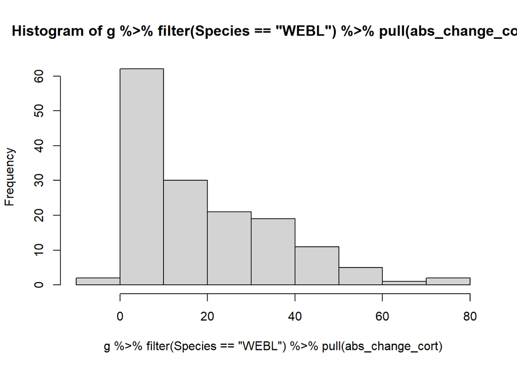

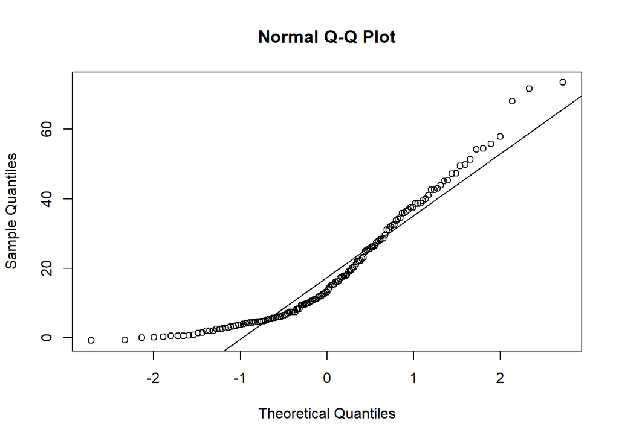

Not great! Needs to be transformed!

### Square root transformation

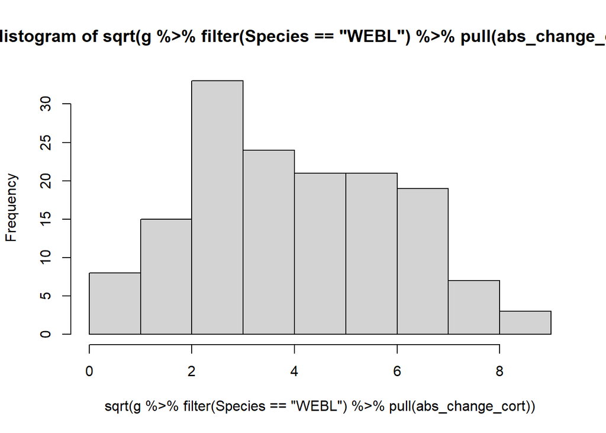

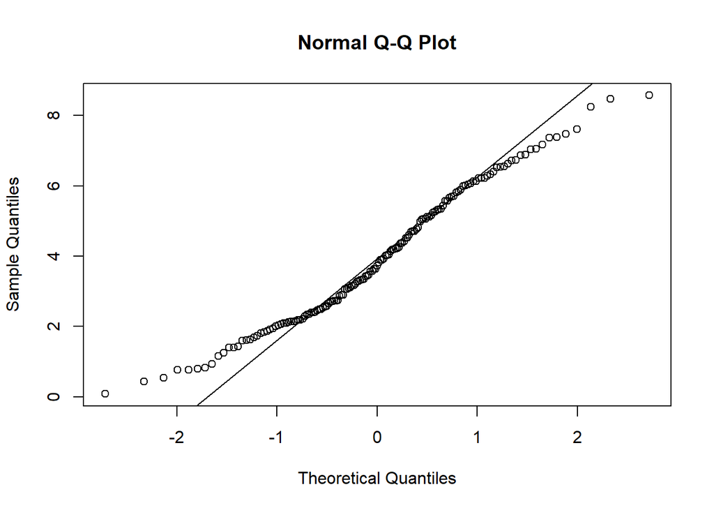

Closer… Maybe try natural log?

### Natural log

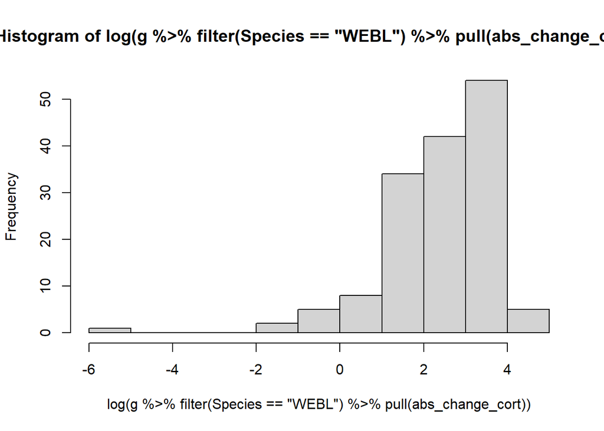

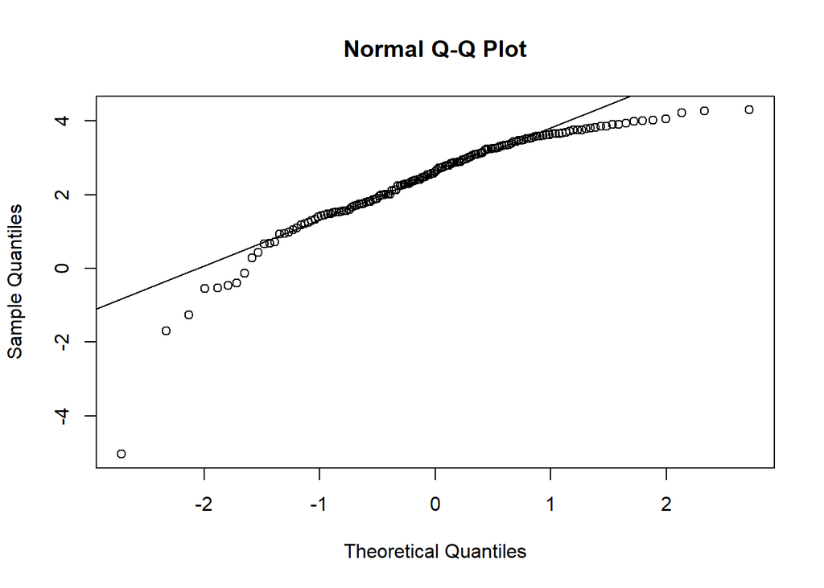

Too far! Looks like sqrt is the best transformation.

### Proportional difference (cort_s2-cort_s1)/cort_s1

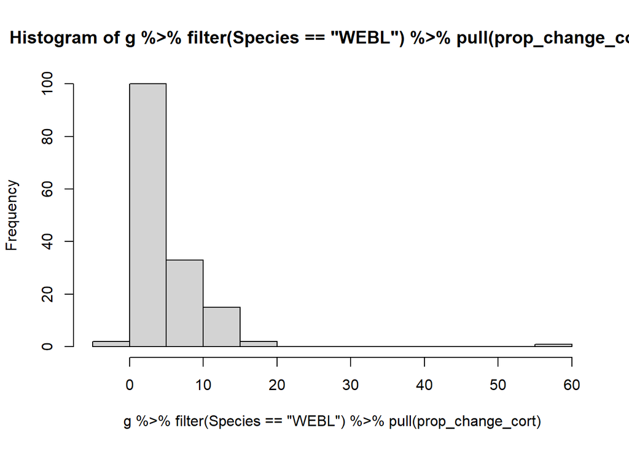

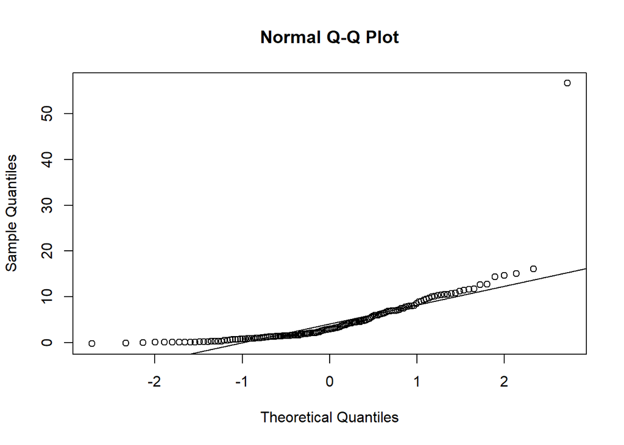

Needs to be transformed.

### Square root transformation

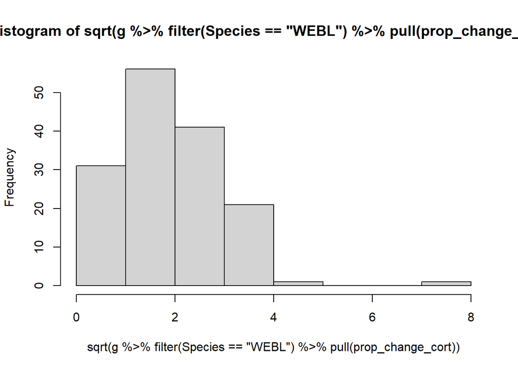

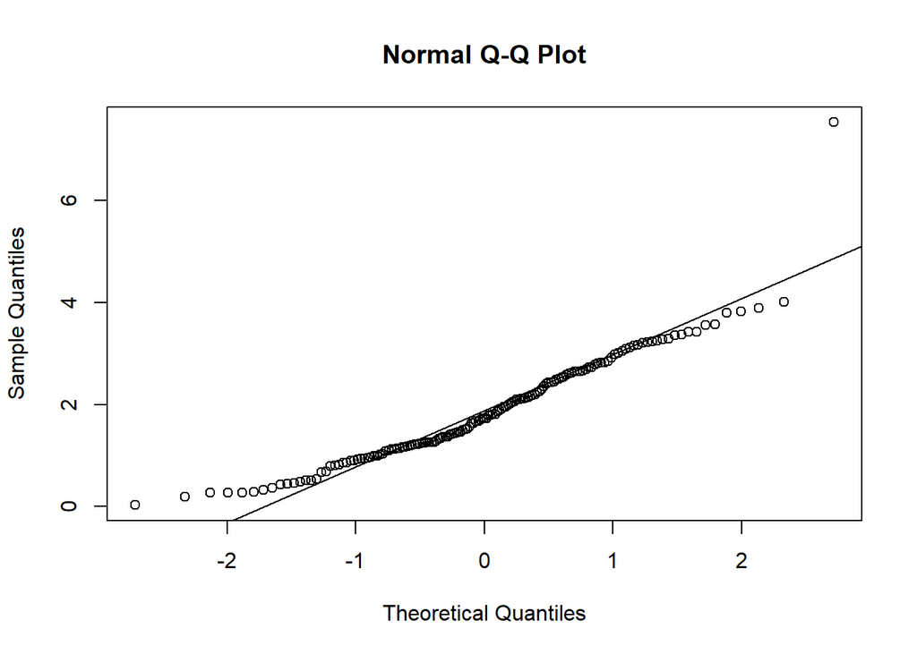

Not quite enough… maybe the natural log? But this does look better.

### Natural log

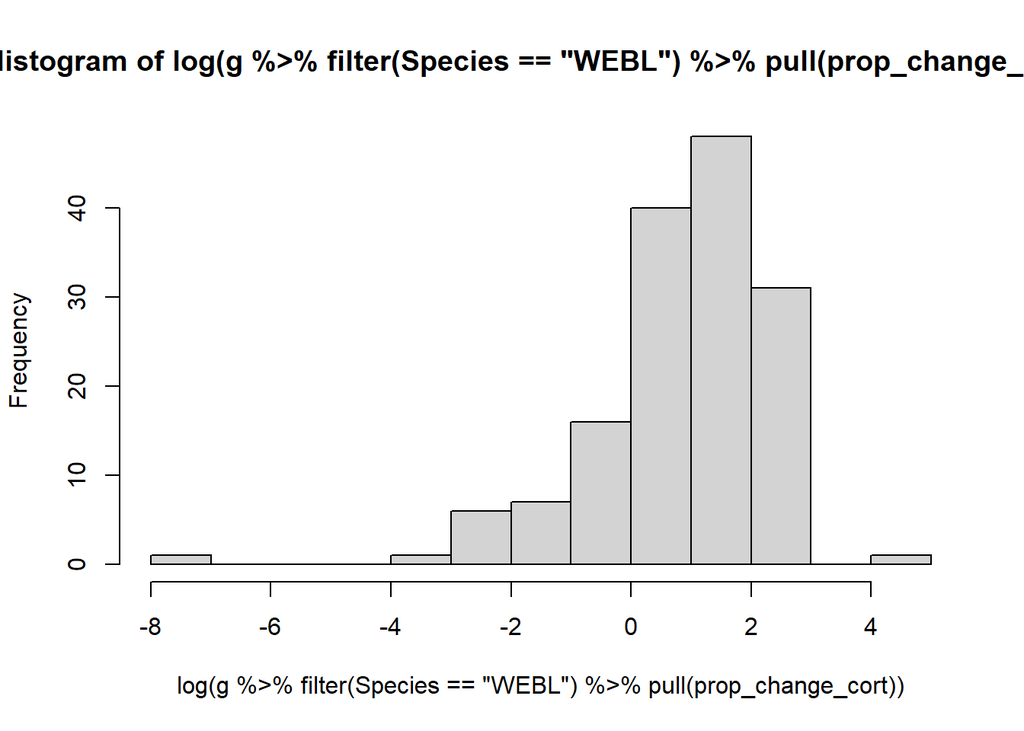

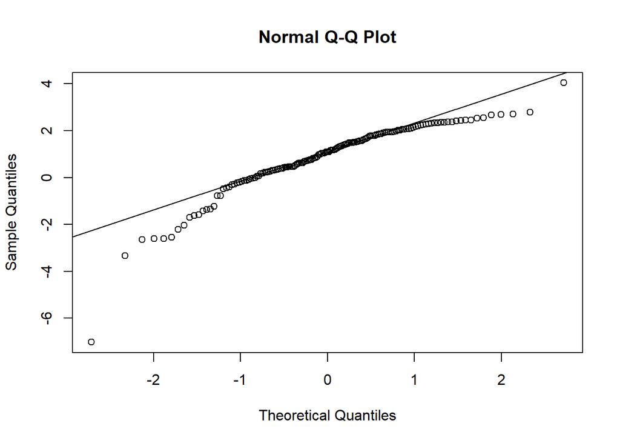

Too far, looks like the square root transformation is the one for all three responses for WEBL.

### Conclusions

Square root transformation for all three cort response variables helps with normality of response variable.

## TRES

### Baseline cort

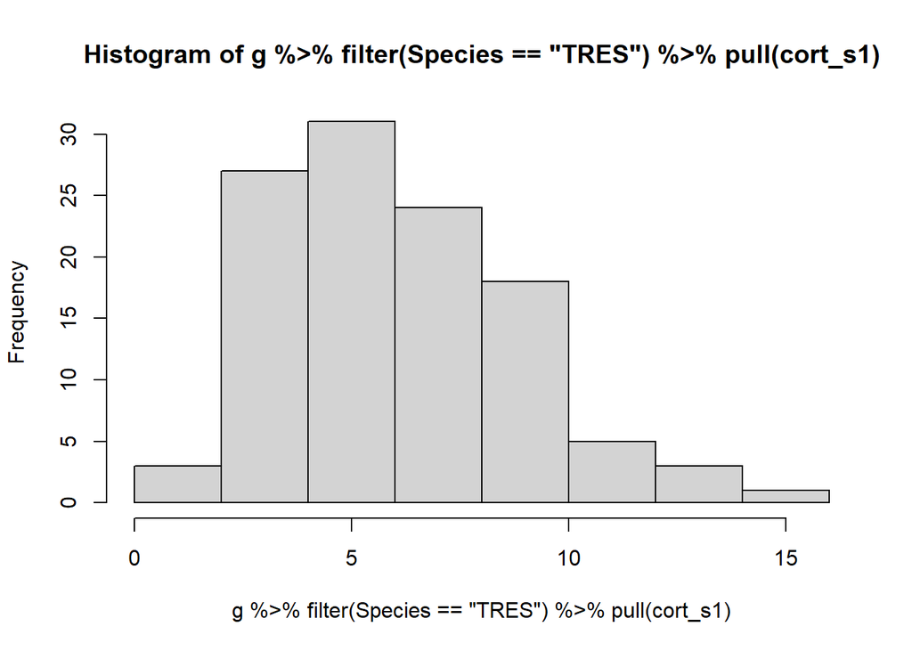

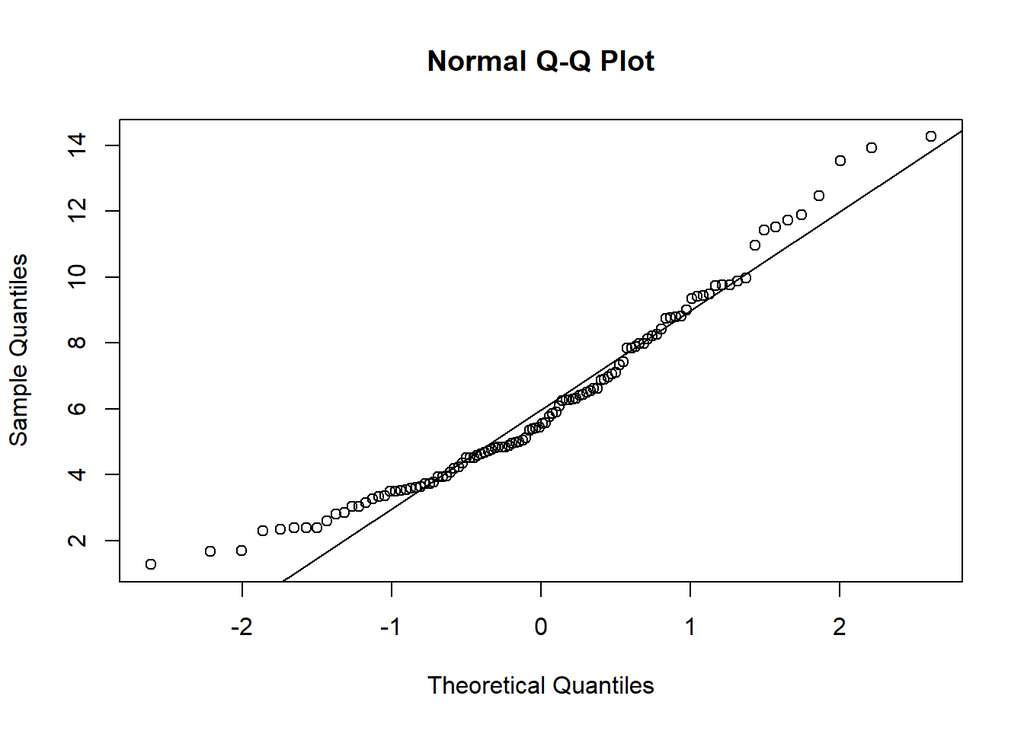

May be basically okay but a transformation may help.

### Square root transformation

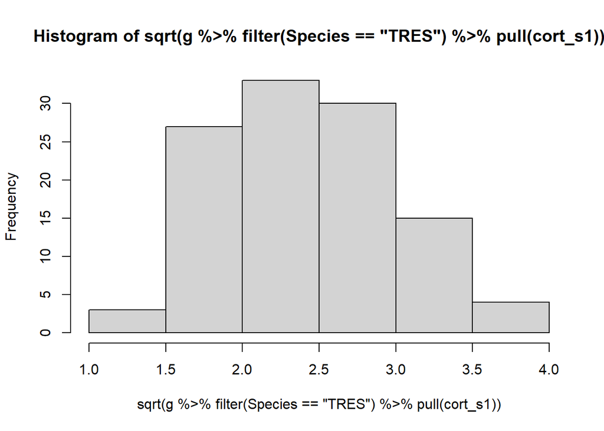

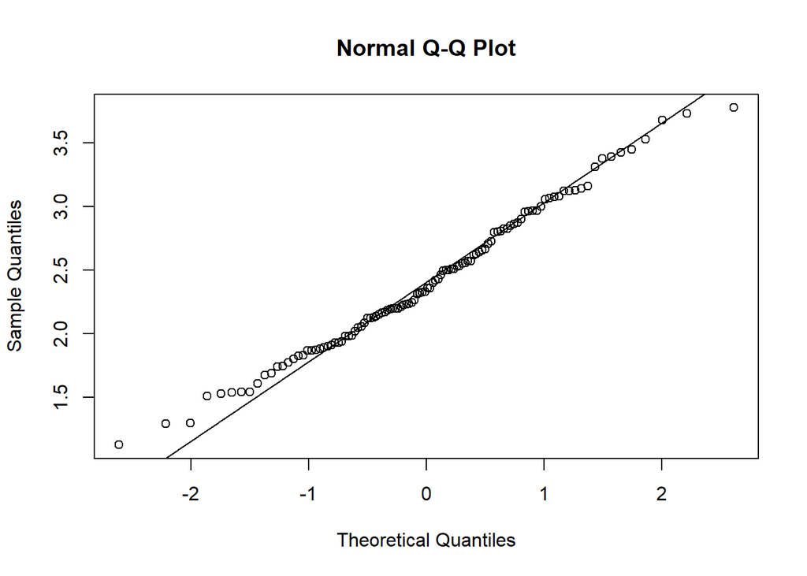

This looks like enough for cort_s1.

### Absolute difference cort_s2-cort_s1

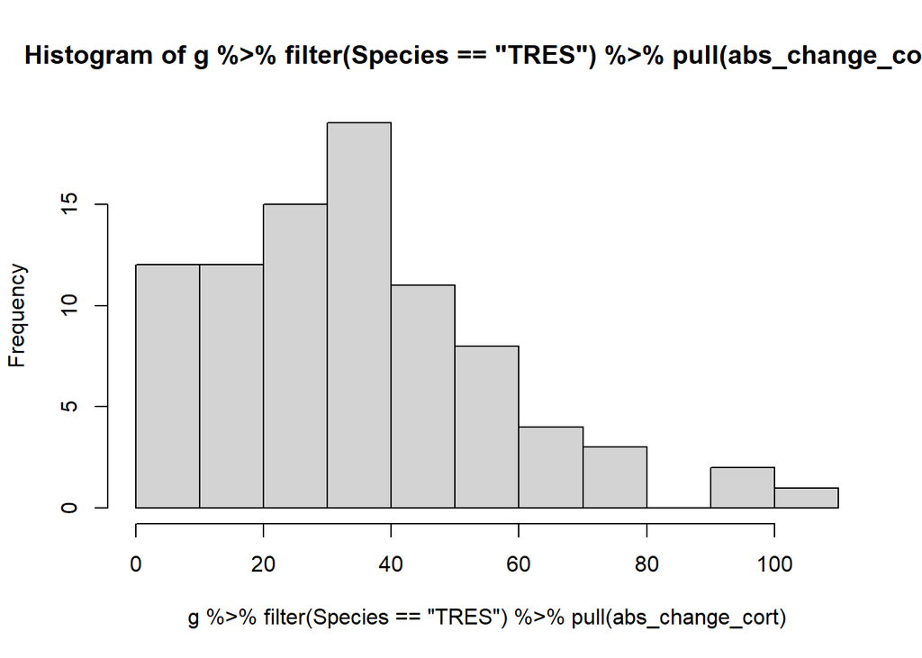

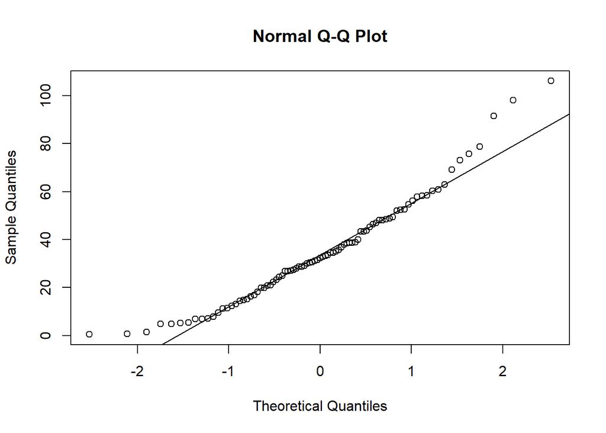

Honestly looks mostly okay to me.

### Square root transformation

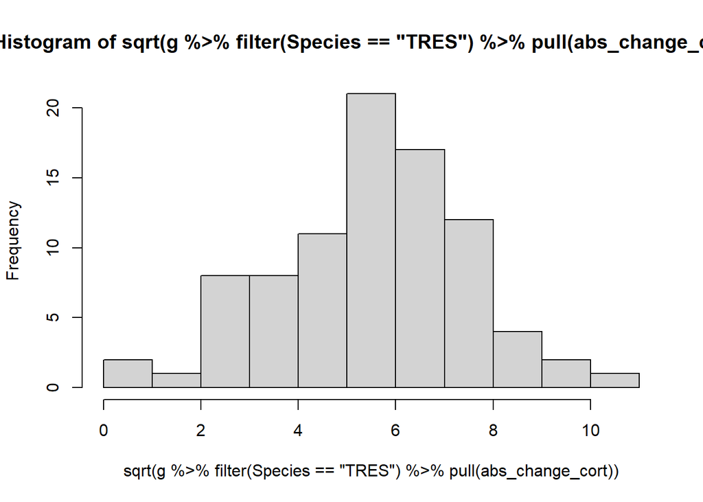

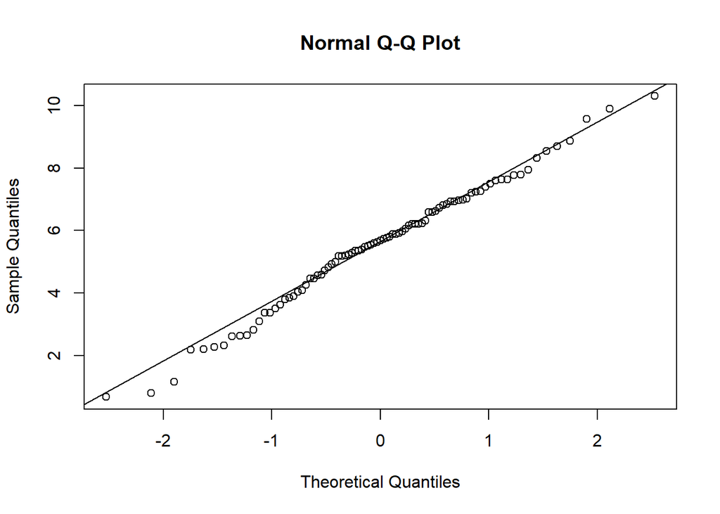

That’s enough for abs change!

### Proportional difference (cort_s2-cort_s1)/cort_s1

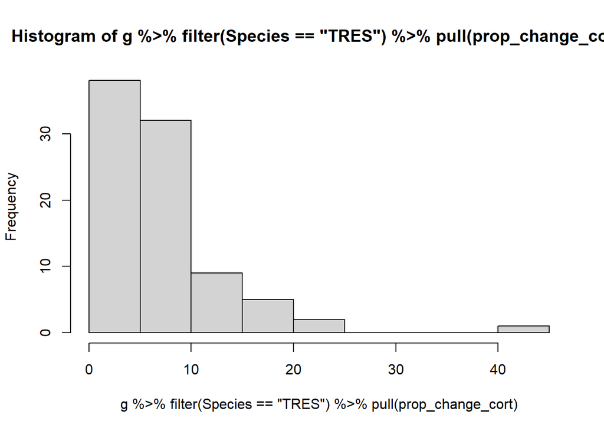

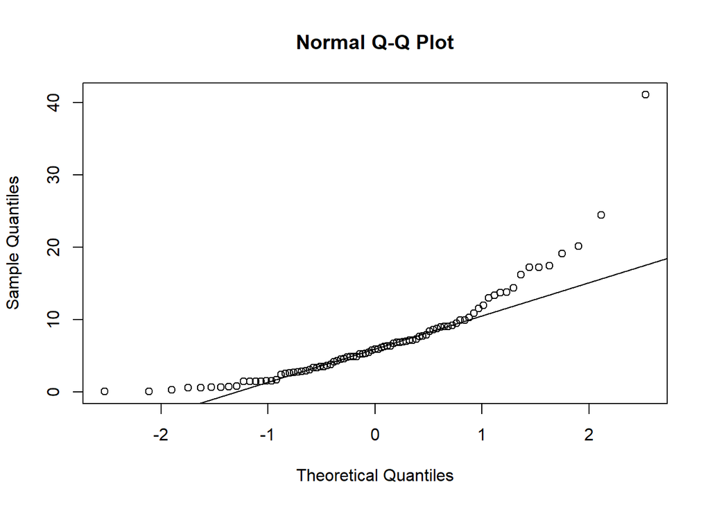

Needs to be transformed.

### Square root transformation

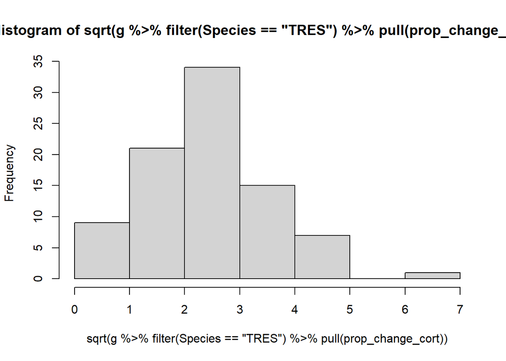

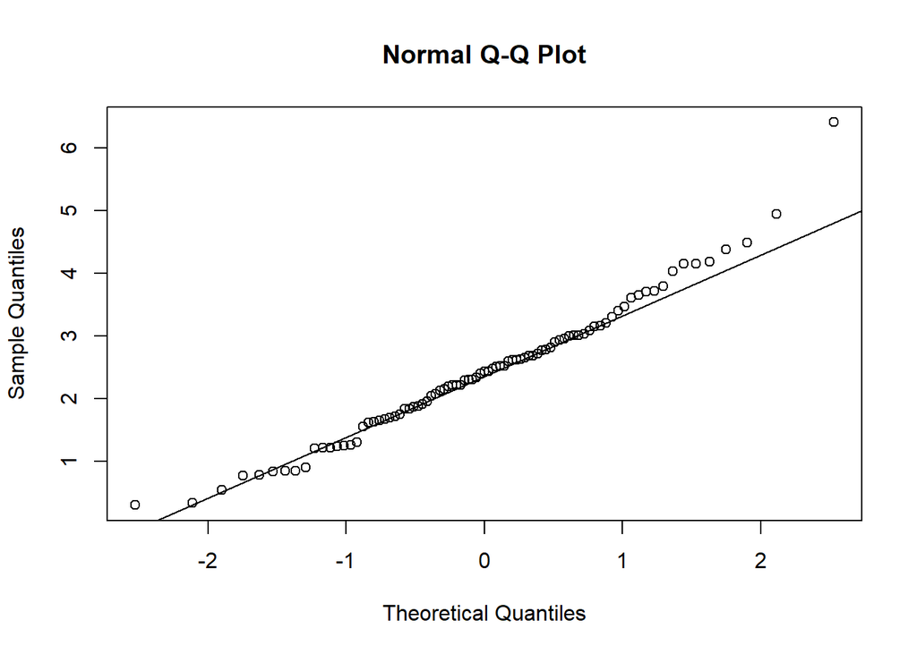

Honestly looks pretty much good. Will try the natural log just in case.

### Natural log

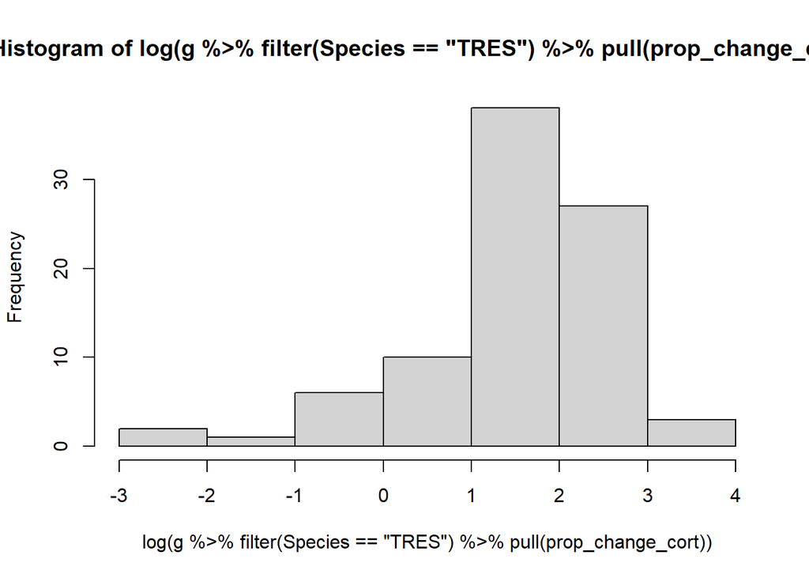

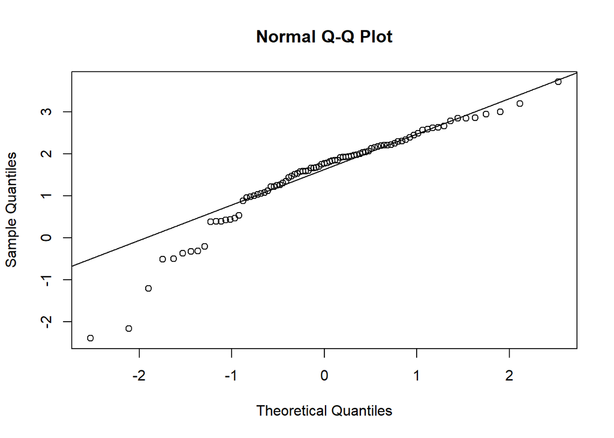

Too far, looks like the square root transformation is the one for all three responses for TRES.

### Conclusions

Square root transformation for all three cort response variables helps with normality of response variable.

## For each response, produce 2 models:

1. linear max and min
2. Squared max

## WEBL

### sqrt(cort_s1)

#### Plots

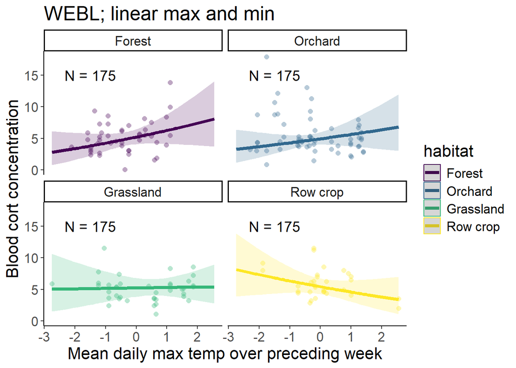

```
## Linear mixed model fit by REML. t-tests use Satterthwaite's method [
## lmerModLmerTest]
## Formula: sqrt(cort_s1) ~ meanmaxtempI_scaled * habitat + meanmintempI_scaled *
##     habitat + age_scaled + juliandate_scaled + year_fct + (1 |      attempt_id)
##    Data:
## dplyr::filter(g, Species == "WEBL", !is.na(meanmaxtempI), !is.na(meanmintempI)) %>%
##     mutate(across(c(gweight, meanmaxtempI, meanmintempI, juliandate,
##         brood_size, age), ~scale(.x)[, 1], .names = "{.col}_scaled"),
##         meanmaxtempI_scaled_sq = meanmaxtempI_scaled * meanmaxtempI_scaled)
##
## REML criterion at convergence: 291.2
##
## Scaled residuals:
##     Min      1Q  Median      3Q     Max
## -3.1893 -0.5083 -0.0135  0.5608  4.0301
##
## Random effects:
##  Groups     Name        Variance Std.Dev.
##  attempt_id (Intercept) 0.08726  0.2954
##  Residual               0.21205  0.4605
## Number of obs: 175, groups:  attempt_id, 52
##
## Fixed effects:
##                                       Estimate Std. Error        df t value
## (Intercept)                            2.28630    0.13053  28.00908  17.516
## meanmaxtempI_scaled                    0.22005    0.15680  50.74281   1.403
## habitatOrchard                        -0.06265    0.16143  28.96864  -0.388
## habitatGrassland                       0.01232    0.20436  31.06650   0.060
## habitatRow crop                        0.06871    0.17869  28.16200   0.385
## meanmintempI_scaled                    0.03929    0.16464  42.16243   0.239
## age_scaled                             0.08611    0.04648 156.71413   1.853
## juliandate_scaled                     -0.25807    0.09123  40.26650  -2.829
## year_fct2023                           0.08780    0.13609  33.98334   0.645
## meanmaxtempI_scaled:habitatOrchard    -0.06964    0.20589  62.19882  -0.338
## meanmaxtempI_scaled:habitatGrassland  -0.20390    0.21282  59.94285  -0.958
## meanmaxtempI_scaled:habitatRow crop   -0.40869    0.21594  46.57705  -1.893
## habitatOrchard:meanmintempI_scaled    -0.02998    0.20492  42.71115  -0.146
## habitatGrassland:meanmintempI_scaled   0.06106    0.28872  70.82186   0.211
## habitatRow crop:meanmintempI_scaled    0.16848    0.20419  38.61287   0.825
##                                      Pr(>|t|)
## (Intercept)                           < 2e-16 ***
## meanmaxtempI_scaled                   0.16658
## habitatOrchard                        0.70080
## habitatGrassland                      0.95231
## habitatRow crop                       0.70347
## meanmintempI_scaled                   0.81255
## age_scaled                            0.06579 .
## juliandate_scaled                     0.00725 **
## year_fct2023                          0.52315
## meanmaxtempI_scaled:habitatOrchard    0.73632
## meanmaxtempI_scaled:habitatGrassland  0.34188
## meanmaxtempI_scaled:habitatRow crop   0.06464 .
## habitatOrchard:meanmintempI_scaled    0.88438
## habitatGrassland:meanmintempI_scaled  0.83312
## habitatRow crop:meanmintempI_scaled   0.41439
## ---
## Signif. codes:  0 '***' 0.001 '**' 0.01 '*' 0.05 '.' 0.1 ' ' 1
```

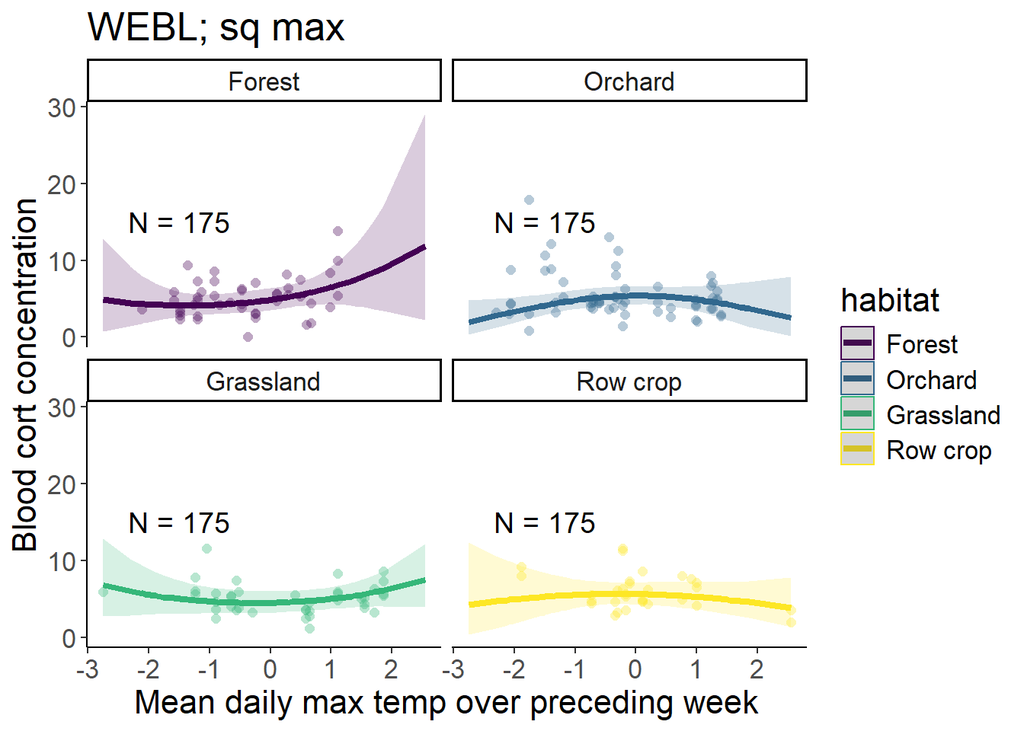

```
## Linear mixed model fit by REML. t-tests use Satterthwaite's method [
## lmerModLmerTest]
## Formula: sqrt(cort_s1) ~ poly(meanmaxtempI_scaled, 2) * habitat + age_scaled +
##     juliandate_scaled + year_fct + (1 | attempt_id)
##    Data:
## dplyr::filter(g, Species == "WEBL", !is.na(meanmaxtempI), !is.na(meanmintempI)) %>%
##     mutate(across(c(gweight, meanmaxtempI, meanmintempI, juliandate,
##         brood_size, age), ~scale(.x)[, 1], .names = "{.col}_scaled"),
##         meanmaxtempI_scaled_sq = meanmaxtempI_scaled * meanmaxtempI_scaled)
##
## REML criterion at convergence: 243.3
##
## Scaled residuals:
##     Min      1Q  Median      3Q     Max
## -3.1295 -0.5178 -0.0560  0.4720  4.2695
##
## Random effects:
##  Groups     Name        Variance Std.Dev.
##  attempt_id (Intercept) 0.1009   0.3176
##  Residual               0.2019   0.4493
## Number of obs: 175, groups:  attempt_id, 52
##
## Fixed effects:
##                                                 Estimate Std. Error        df
## (Intercept)                                      2.29246    0.13646  32.03445
## poly(meanmaxtempI_scaled, 2)1                    4.82528    2.95084  63.25467
## poly(meanmaxtempI_scaled, 2)2                    2.54015    3.32999 150.37838
## habitatOrchard                                  -0.09520    0.16464  31.43897
## habitatGrassland                                -0.09689    0.18874  30.35384
## habitatRow crop                                  0.02585    0.18732  31.40123
## age_scaled                                       0.09238    0.04499 159.56512
## juliandate_scaled                               -0.18310    0.08269  45.01897
## year_fct2023                                     0.11597    0.13962  37.20338
## poly(meanmaxtempI_scaled, 2)1:habitatOrchard    -4.00080    3.44983  54.97710
## poly(meanmaxtempI_scaled, 2)2:habitatOrchard    -5.77262    3.83325 139.09468
## poly(meanmaxtempI_scaled, 2)1:habitatGrassland  -4.39043    3.42805  60.99364
## poly(meanmaxtempI_scaled, 2)2:habitatGrassland  -0.35096    3.63866 156.74542
## poly(meanmaxtempI_scaled, 2)1:habitatRow crop   -5.15786    4.20948  53.38157
## poly(meanmaxtempI_scaled, 2)2:habitatRow crop   -3.92819    3.76745 137.21457
##                                                t value Pr(>|t|)
## (Intercept)                                     16.799   <2e-16 ***
## poly(meanmaxtempI_scaled, 2)1                    1.635   0.1070
## poly(meanmaxtempI_scaled, 2)2                    0.763   0.4468
## habitatOrchard                                  -0.578   0.5672
## habitatGrassland                                -0.513   0.6114
## habitatRow crop                                  0.138   0.8911
## age_scaled                                       2.053   0.0417 *
## juliandate_scaled                               -2.214   0.0319 *
## year_fct2023                                     0.831   0.4115
## poly(meanmaxtempI_scaled, 2)1:habitatOrchard    -1.160   0.2512
## poly(meanmaxtempI_scaled, 2)2:habitatOrchard    -1.506   0.1344
## poly(meanmaxtempI_scaled, 2)1:habitatGrassland  -1.281   0.2051
## poly(meanmaxtempI_scaled, 2)2:habitatGrassland  -0.096   0.9233
## poly(meanmaxtempI_scaled, 2)1:habitatRow crop   -1.225   0.2258
## poly(meanmaxtempI_scaled, 2)2:habitatRow crop   -1.043   0.2989
## ---
## Signif. codes:  0 '***' 0.001 '**' 0.01 '*' 0.05 '.' 0.1 ' ' 1
```

[output not shown]

[output cut: 165 more lines]

[output not shown]

[output cut: 165 more lines]

| Term | VIF | VIF_CI_low | VIF_CI_high | SE_factor | Tolerance | Tolerance_CI_low | Tolerance_CI_high |
| --- | --- | --- | --- | --- | --- | --- | --- |
| meanmaxtempI_scaled | 10.179809 | 7.927601 | 13.164225 | 3.190581 | 0.09823367 | 0.07596345 | 0.12614157 |
| habitat | 2.233063 | 1.847301 | 2.794456 | 1.494344 | 0.44781541 | 0.35785145 | 0.54133027 |
| meanmintempI_scaled | 10.935601 | 8.506261 | 14.151176 | 3.306902 | 0.09144445 | 0.07066551 | 0.11756046 |
| age_scaled | 1.160203 | 1.053320 | 1.481335 | 1.077127 | 0.86191839 | 0.67506663 | 0.94937893 |
| juliandate_scaled | 2.754638 | 2.245129 | 3.472639 | 1.659710 | 0.36302410 | 0.28796547 | 0.44540864 |
| year_fct | 1.308967 | 1.153588 | 1.621537 | 1.144101 | 0.76396103 | 0.61669871 | 0.86686049 |
| meanmaxtempI_scaled:habitat | 49.454743 | 38.000185 | 64.455416 | 7.032407 | 0.02022051 | 0.01551460 | 0.02631566 |
| habitat:meanmintempI_scaled | 60.729315 | 46.633203 | 79.179721 | 7.792902 | 0.01646651 | 0.01262950 | 0.02144395 |

| Term | VIF | VIF_CI_low | VIF_CI_high | SE_factor | Tolerance | Tolerance_CI_low | Tolerance_CI_high |
| --- | --- | --- | --- | --- | --- | --- | --- |
| poly(meanmaxtempI_scaled, 2) | 103.498293 | 79.381761 | 135.035010 | 10.173411 | 0.009661995 | 0.007405487 | 0.01259735 |
| habitat | 1.466389 | 1.268239 | 1.810916 | 1.210946 | 0.681947124 | 0.552206788 | 0.78849508 |
| age_scaled | 1.109150 | 1.024604 | 1.484224 | 1.053162 | 0.901591657 | 0.673752828 | 0.97598724 |
| juliandate_scaled | 2.126215 | 1.765973 | 2.655880 | 1.458155 | 0.470319404 | 0.376523067 | 0.56626003 |
| year_fct | 1.285786 | 1.137172 | 1.595407 | 1.133925 | 0.777734628 | 0.626799318 | 0.87937412 |
| poly(meanmaxtempI_scaled, 2):habitat | 115.412170 | 88.504321 | 150.594267 | 10.743006 | 0.008664597 | 0.006640359 | 0.01129888 |